# Economic and Health Impact of Extreme Weather On U.S., 1950-2011

## Synopsis

Each year, natural disasters cause millions of dollars in damage to American property, and cause injuries and deaths. Using the data from the U.S. National Oceanic and Atmospheric Administration’s storm database, we have conducted an exploratory analysis to determine the most harmful of these events.

We find that tornadoes are the most destructive to human life, causing the greatest number of deaths and injuries. Drought causes the most damage to American crops, and flooding causes the greatest amout of damage to American property.

## Data Processing

Code is included to download the raw data, if the file is not in the current working directory. Then, the file is read directly by read.csv. We will also be using the dplyr and ggplot2 packages; these are loaded.

```r
if (!file.exists("repdata%2Fdata%2FStormData.csv.bz2")) {
  download.file(
    "https://d396qusza40orc.cloudfront.net/repdata%2Fdata%2FStormData.csv.bz2",
    destfile = "repdata%2Fdata%2FStormData.csv.bz2")
}
storm.data <- read.csv("repdata%2Fdata%2FStormData.csv.bz2", stringsAsFactors = FALSE)
library(dplyr)
library(ggplot2)
```

For processing the data, we will use the dplyr package and a helper function called “cost.multiplier,” which will be used to map the symbolic multipliers in the data set (e.g. “K” for one thousand) to the corresponding numbers, so that it is possible to calculate the economic damage.

```r
cost.multiplier <- function(x) {
  if (x == "") {
    0
  }
  else{
    switch(x,
           "b" =,
           "B" = 1000000000,
           "h" =,
           "H" = 100,
           "K" =,
           "k" = 1000,
           "m" =,
           "M" = 1000000,
           "?" =,
           "-" = 0,
           "+" = 1,
           10)
  }
}
storm.data$PROPDMGMULT <- sapply(storm.data$PROPDMGEXP, cost.multiplier)
storm.data$CROPDMGMULT <- sapply(storm.data$CROPDMGEXP, cost.multiplier)
```

A data frame tbl is created from the data frame, and the columns we will need are extracted. We will only requier the data on fatalities, injuries, property and crop damage (and the corresponding multipliers). The actual economic damage is calculated by multiplying the value in PROPDMG (likewise, CROPDMG) with the associated value in PROPDMGMULT (CROPDMGMULT).

```r
storm.data <- tbl_df(storm.data)
storm.data <- storm.data %>%
  select(EVTYPE, FATALITIES, INJURIES, PROPDMG, PROPDMGMULT,
         CROPDMG, CROPDMGMULT) %>%
  mutate(PROPCOST = PROPDMG * PROPDMGMULT,
         CROPCOST = CROPDMG * CROPDMGMULT)
head(storm.data)
```

```
## # A tibble: 6 x 9
##    EVTYPE FATALITIES INJURIES PROPDMG PROPDMGMULT CROPDMG CROPDMGMULT
##     <chr>      <dbl>    <dbl>   <dbl>       <dbl>   <dbl>       <dbl>
## 1 TORNADO          0       15    25.0        1000       0           0
## 2 TORNADO          0        0     2.5        1000       0           0
## 3 TORNADO          0        2    25.0        1000       0           0
## 4 TORNADO          0        2     2.5        1000       0           0
## 5 TORNADO          0        2     2.5        1000       0           0
## 6 TORNADO          0        6     2.5        1000       0           0
## # ... with 2 more variables: PROPCOST <dbl>, CROPCOST <dbl>
```

Next, the data are grouped by EVTYPE – the kind of event. Sums are run to find the total number of deaths, of injuries, and the economic cost to property and to crops for each category of event.

```r
grouped.data <- group_by(storm.data, EVTYPE)
property.damage <- grouped.data %>%
  summarize(EXPENSE = sum(PROPCOST)) %>%
  arrange(desc(EXPENSE))
crop.damage <- grouped.data %>%
  summarize(EXPENSE = sum(CROPCOST)) %>%
  arrange(desc(EXPENSE))
fatalities <- grouped.data %>%
  summarize(DEATHS = sum(FATALITIES)) %>%
  arrange(desc(DEATHS))
injuries <- grouped.data %>%
  summarize(INJURED = sum(INJURIES)) %>%
  arrange(desc(INJURED))
```

## Results

### Fatalities

An examination of the fatality data shows us that tornadoes are by far, the most deadly of the tracked storms. Excessive heat are second, with flash flood a distant third. The ten most deadly tracked categries are charted, for purposes of comparison.

```r
head(fatalities)
```

```
## # A tibble: 6 x 2
##           EVTYPE DEATHS
##            <chr>  <dbl>
## 1        TORNADO   5633
## 2 EXCESSIVE HEAT   1903
## 3    FLASH FLOOD    978
## 4           HEAT    937
## 5      LIGHTNING    816
## 6      TSTM WIND    504
```

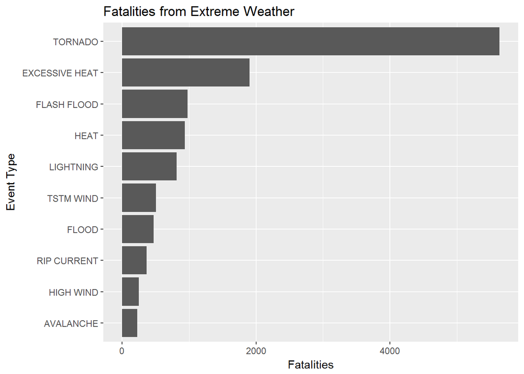

```r
fatality.plot <- ggplot(data = head(fatalities, 10),
                      aes(x = reorder(EVTYPE, DEATHS), y = DEATHS)) +
  geom_col() +
  labs(x="Event Type",
       y="Fatalities",
       title="Fatalities from Extreme Weather") +
  coord_flip()
print(fatality.plot)
```

### Injuries

An examination of our injury data again shows tornadoes as the most harmful of tracked phenomena, with more than ten times a many injuries as TSTM (thunderstorm) wind, which is second.

```r
head(injuries)
```

```
## # A tibble: 6 x 2
##           EVTYPE INJURED
##            <chr>   <dbl>
## 1        TORNADO   91346
## 2      TSTM WIND    6957
## 3          FLOOD    6789
## 4 EXCESSIVE HEAT    6525
## 5      LIGHTNING    5230
## 6           HEAT    2100
```

### Damage to Property

We find that floods have been most destructive to property – more than twice as damaging as hurricanes and typhoons. Again, the top ten are charted for demonstration.

```r
head(property.damage)
```

```
## # A tibble: 6 x 2
##              EVTYPE      EXPENSE
##               <chr>        <dbl>
## 1             FLOOD 144657709800
## 2 HURRICANE/TYPHOON  69305840000
## 3           TORNADO  56937162897
## 4       STORM SURGE  43323536000
## 5       FLASH FLOOD  16140815011
## 6              HAIL  15732269877
```

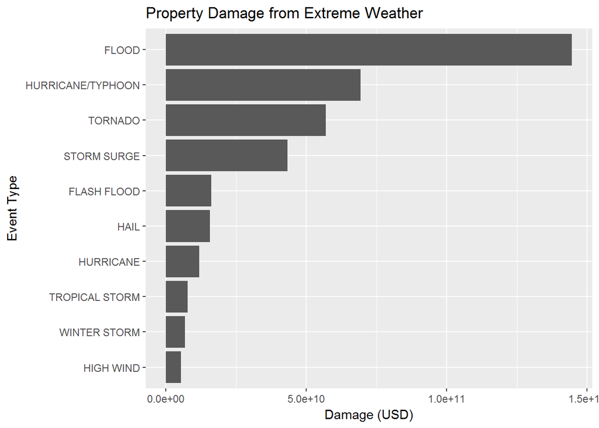

```r
property.plot <- ggplot(data = head(property.damage, 10),
                  aes(x = reorder(EVTYPE, EXPENSE), y = EXPENSE)) +
  geom_col() +
  labs(x="Event Type",
       y="Damage (USD)",
       title="Property Damage from Extreme Weather") +
  coord_flip()
print(property.plot)
```

### Damage to Crops

Though various floods and freezes are individually damaging, the single most destructive extreme weather event to crops is found to be drought.

```r
head(crop.damage)
```

```
## # A tibble: 6 x 2
##        EVTYPE     EXPENSE
##         <chr>       <dbl>
## 1     DROUGHT 13972566000
## 2       FLOOD  5661968450
## 3 RIVER FLOOD  5029459000
## 4   ICE STORM  5022113500
## 5        HAIL  3025954650
## 6   HURRICANE  2741910000
```